# Project 4

```r
library(tidyr)
library(readxl)
library(stringr)
library(dplyr)
library(magrittr)
```

```r
library(ggplot2)
library(knitr)
library(janitor)
athletes_data <- read_excel("olympics.xlsx", sheet = "athletes") %>% clean_names()
country_data<-read_excel("olympics.xlsx",sheet = "country")%>% clean_names()
games_data<-read_excel("olympics.xlsx", sheet = "games")%>% clean_names()
medals_data<-read_excel("olympics.xlsx", sheet = "medals")%>% clean_names()
```

# Part 1

some athletes competed for different countries over time

```r
athlete_participated_different_country<-country_data %>%
  select(-age,-games)%>%
  group_by(athlete_id)%>%
  distinct(noc) %>%
  mutate(participation=n()) %>%
  filter(participation!=1)

athlete_participated_different_country %>%
  arrange(desc(participation)) %>%
  #filter(participation!=1) %>%
  top_n(5) %>%
  knitr::kable(caption = "Athlete participation for different country") %>%
  kableExtra::kable_styling(
    bootstrap_options = "striped",
    full_width = F,
    position = "left"
  )
```

Athlete participation for different country

| noc | athlete_id | participation |
| --- | --- | --- |
| URS | 59021 | 4 |
| EUN | 59021 | 4 |
| RUS | 59021 | 4 |
| UZB | 59021 | 4 |
| URS | 66953 | 4 |
| EUN | 66953 | 4 |
| RUS | 66953 | 4 |
| AUS | 66953 | 4 |
| YUG | 72433 | 4 |
| IOA | 72433 | 4 |
| SCG | 72433 | 4 |
| USA | 72433 | 4 |
| YUG | 108383 | 4 |
| IOA | 108383 | 4 |
| SCG | 108383 | 4 |
| SRB | 108383 | 4 |
| URS | 111969 | 4 |
| EUN | 111969 | 4 |
| UKR | 111969 | 4 |
| POL | 111969 | 4 |
| CUB | 2425 | 3 |
| SUD | 2425 | 3 |
| GBR | 2425 | 3 |
| URS | 4677 | 3 |
| EUN | 4677 | 3 |
| RUS | 4677 | 3 |
| URS | 5447 | 3 |
| EUN | 5447 | 3 |
| NED | 5447 | 3 |
| EUN | 5839 | 3 |

[output cut: 3212 more lines]

```r
  athlete_number<-athlete_participated_different_country%>%
  group_by(athlete_id) %>%
  summarise(total_number=n()) %>%
  ungroup()

  athlete_number<-athlete_participated_different_country%>%
  distinct(athlete_id,participation) %>%
  count(athlete_id,participation)
```

Yes, 1570 athletes have participated for different (more than 1) countries.

# Part 2

ten athletes that took part in most games

```r
medals_athletes_left_join<-medals_data%>%
  left_join(athletes_data,
            by = c("athlete_id" ="id"))

Participation_number_of_games<-medals_athletes_left_join%>%
  distinct(athlete_id,games,name) %>%
  group_by(name) %>%
  summarise(number_of_games=n())%>%
  arrange(desc(number_of_games))%>%
  top_n(10)

Participation_number_of_games_table<-Participation_number_of_games %>%
 knitr::kable(caption = "ten athletes that took part in most number of games") %>%
    kableExtra::kable_styling(
      bootstrap_options = "striped",
      full_width = F,
      position = "left"
    )
```

ten athletes that took part in most number of games

| name | number_of_games |
| --- | --- |
| Ian Millar | 10 |
| Afanasijs Kuzmins | 9 |
| Hubert Raudaschl | 9 |
| Aleksandr Vladimirovich Popov | 8 |
| Chen Jing | 8 |
| Durward Randolph Knowles | 8 |
| Francisco Boza Dibos | 8 |
| Josefa Idem-Guerrini | 8 |
| Lesley Allison Thompson-Willie | 8 |
| Li Na | 8 |
| Nino Salukvadze (-Machavariani) | 8 |
| Paul Bert Elvstrm | 8 |
| Piero D’Inzeo | 8 |
| Raimondo D’Inzeo | 8 |
| Rajmond Debevec | 8 |

.

# Part 3

athlete(s) kept a Gold medal for the longest time

```r
games_id_data<-games_data %>%
  filter(!(year==1956 & city =="Stockholm")) %>%
  arrange(season, year)

games_id_data<-games_id_data %>%
  mutate(game_id=seq(1,nrow(games_id_data)))

  #mutate(year=as.numeric(str_sub(games,start = 1L,end = 4L)))%>%
  #mutate(session=str_sub(games,start = 6L))

medal_game_left_join<-left_join(games_id_data, medals_data, by=c("games"))

athlete_longest_sequence_data<-medal_game_left_join %>%
  filter(medal=="Gold") %>%
  distinct(athlete_id,event,game_id) %>%
  arrange(athlete_id,event,game_id) %>%
  group_by(athlete_id,event) %>%
  mutate(previous_game=lag(game_id,default=0)) %>%
  mutate(diff=game_id-previous_game) %>%
  mutate(gold_won_previous_game=if_else(diff==1,1,0)) %>%
  mutate(interruption=1-gold_won_previous_game) %>%
  mutate(sequence_number=cumsum(interruption)) %>%
  count(sequence_number)

athlete_longest_sequence_data%>%
  arrange(desc(n)) %>%
  head(20) %>%
 knitr::kable(caption = "athlete(s) kept a Gold medal for the longest time",
              knitr.table.format = "html") %>%
    kableExtra::kable_styling(
      bootstrap_options = "striped",
      full_width = F,
      position = "left"
    )
```

athlete(s) kept a Gold medal for the longest time

| athlete_id | event | sequence_number | n |
| --- | --- | --- | --- |
| 39726 | Fencing Men’s Sabre, Team | 1 | 6 |
| 63409 | Fencing Men’s Sabre, Team | 1 | 5 |
| 11671 | Basketball Women’s Basketball | 1 | 4 |
| 19044 | Basketball Women’s Basketball | 1 | 4 |
| 32458 | Sailing Mixed One Person Dinghy | 1 | 4 |
| 33557 | Athletics Men’s Standing High Jump | 1 | 4 |
| 33557 | Athletics Men’s Standing Long Jump | 1 | 4 |
| 47137 | Ice Hockey Women’s Ice Hockey | 1 | 4 |
| 57699 | Fencing Men’s Sabre, Team | 1 | 4 |
| 68985 | Basketball Women’s Basketball | 1 | 4 |
| 69210 | Athletics Men’s Long Jump | 1 | 4 |
| 70965 | Swimming Men’s 4 x 200 metres Freestyle Relay | 1 | 4 |
| 88073 | Athletics Men’s Discus Throw | 1 | 4 |
| 90081 | Ice Hockey Women’s Ice Hockey | 1 | 4 |
| 94406 | Swimming Men’s 200 metres Individual Medley | 1 | 4 |
| 94406 | Swimming Men’s 4 x 100 metres Medley Relay | 1 | 4 |
| 94406 | Swimming Men’s 4 x 200 metres Freestyle Relay | 1 | 4 |
| 118778 | Basketball Women’s Basketball | 1 | 4 |
| 120316 | Biathlon Men’s 4 x 7.5 kilometres Relay | 1 | 4 |
| 130148 | Ice Hockey Women’s Ice Hockey | 1 | 4 |

Fencing athlete(s) kept a Gold medal for the longest time.

# Part 4

country(ies) kept a Gold medal for the longest time

```r
country_longest_sequence_data<-medal_game_left_join %>%
  filter(medal=="Gold") %>%
  distinct(team,event,game_id) %>%
  arrange(team,event,game_id) %>%
  group_by(team,event) %>%
  mutate(previous_game=lag(game_id,default=0)) %>%
  mutate(diff=game_id-previous_game) %>%
  mutate(gold_won_previous_game=if_else(diff==1,1,0)) %>%
  mutate(interruption=1-gold_won_previous_game) %>%
  mutate(sequence_number=cumsum(interruption)) %>%
  count(sequence_number)

country_longest_sequence_data %>%
  arrange(desc(n)) %>%
  head(20) %>%
 knitr::kable(caption = "Countries kept a Gold medal for the longest time") %>%
    kableExtra::kable_styling(
      bootstrap_options = "striped",
      full_width = F,
      position = "left"
    )
```

Countries kept a Gold medal for the longest time

| team | event | sequence_number | n |
| --- | --- | --- | --- |
| United States | Athletics Men’s Pole Vault | 1 | 13 |
| United States | Diving Men’s Springboard | 2 | 11 |
| Hungary | Fencing Men’s Sabre, Individual | 2 | 9 |
| Kenya | Athletics Men’s 3,000 metres Steeplechase | 2 | 9 |
| United States | Athletics Men’s 110 metres Hurdles | 2 | 9 |
| United States | Swimming Men’s 4 x 100 metres Medley Relay | 2 | 9 |
| China | Diving Women’s Springboard | 1 | 8 |
| China | Table Tennis Women’s Singles | 1 | 8 |
| South Korea | Archery Women’s Team | 1 | 8 |
| Soviet Union | Gymnastics Women’s Team All-Around | 1 | 8 |
| United States | Athletics Men’s 4 x 100 metres Relay | 1 | 8 |
| United States | Athletics Men’s Long Jump | 1 | 8 |
| United States | Diving Women’s Springboard | 1 | 8 |
| United States | Rowing Men’s Coxed Eights | 1 | 8 |
| Hungary | Fencing Men’s Sabre, Team | 2 | 7 |
| Soviet Union | Gymnastics Women’s Floor Exercise | 1 | 7 |
| Soviet Union-1 | Figure Skating Mixed Pairs | 1 | 7 |
| United States | Athletics Men’s 400 metres | 4 | 7 |
| United States | Basketball Men’s Basketball | 1 | 7 |
| United States | Diving Men’s Platform | 1 | 7 |

United States kept the gold for the longest time.

# Part 5

ten athletes that competed in the most events (some athletes take part in more than one event during games)

```r
athletes_participated_most_events<-medals_athletes_left_join%>%
  distinct(athlete_id,event,name) %>%
  group_by(name) %>%
  summarise(number_of_events=n())%>%
  arrange(desc(number_of_events))%>%
  top_n(10)

athletes_participated_most_events %>%
 knitr::kable(caption = "10 athletes that participated in most number of events") %>%
    kableExtra::kable_styling(
      bootstrap_options = "striped",
      full_width = F,
      position = "left"
    )
```

10 athletes that participated in most number of events

| name | number_of_events |
| --- | --- |
| Ioannis Theofilakis | 33 |
| Alexandros Theofilakis | 28 |
| Gustaf Eric Carlberg | 24 |
| Frangiskos D. Mavrommatis | 22 |
| Gustaf Vilhelm Carlberg | 22 |
| Paul Van Asbroeck | 20 |
| Lars Jrgen Madsen | 19 |
| Lon Ernest Moreaux | 19 |
| Georgios D. Orfanidis | 18 |
| Johan Hbner von Holst | 18 |
| Lon douard Johnson | 18 |
| Marie Joseph “Raoul” le Borgne de Boigne | 18 |

# Part 6

number of medals per country (rows) and per year (column)

```r
top_15 <- medals_data %>%
  mutate(team = stringr::str_extract(team, "\\D+")) %>%
  mutate(team = stringr::str_replace_all(team, "[[:punct:]]", " ")) %>%
  filter(complete.cases(.)) %>%
  mutate(year = as.numeric(str_sub(games, start = 1L, end = 4L))) %>%
  distinct(session,year, team, event, medal) %>%
  count(team) %>%
  top_n(15) %>%
  pull(team)

top_15_year <- medals_data %>%
  mutate(team = stringr::str_extract(team, "\\D+")) %>%
  mutate(team = stringr::str_replace_all(team, "[[:punct:]]", " ")) %>%
  filter(complete.cases(.)) %>%
  mutate(year = as.numeric(str_sub(games, start = 1L, end = 4L))) %>%
  distinct(session,year, team, event, medal) %>%
  filter(team %in% top_15 ) %>%
  count(team,year)

number_of_medals_per_country_pivoted <-
  top_15_year %>%
  arrange(year) %>%
  tidyr::pivot_wider(names_from = year,
                     values_from = n)

number_of_medals_per_country_pivoted %>%
  knitr::kable(caption = "Number of medals per country (rows) and per year (column)") %>%
  kableExtra::kable_styling(
    bootstrap_options = "striped",
    full_width = F,
    position = "left"
  )
```

Number of medals per country (rows) and per year (column)

| team | 1896 | 1900 | 1904 | 1906 | 1908 | 1912 | 1920 | 1924 | 1928 | 1932 | 1936 | 1948 | 1952 | 1956 | 1960 | 1964 | 1968 | 1972 | 1976 | 1980 | 1984 | 1988 | 1992 | 1994 | 1996 | 1998 | 2000 | 2002 | 2004 | … |
| --- | --- | --- | --- | --- | --- | --- | --- | --- | --- | --- | --- | --- | --- | --- | --- | --- | --- | --- | --- | --- | --- | --- | --- | --- | --- | --- | --- | --- | --- | --- |
| Australia | 2 | 5 | 4 | 3 | NA | NA | 3 | 7 | 4 | 5 | 1 | 13 | 11 | 33 | 22 | 17 | 17 | 17 | 5 | 9 | 24 | 14 | 27 | 1 | 40 | 1 | 57 | 2 | 50 | … |
| France | 11 | 66 | 1 | 36 | 17 | 14 | 39 | 39 | 25 | 21 | 20 | 37 | 19 | 14 | 8 | 22 | 24 | 16 | 10 | 15 | 31 | 18 | 36 | 5 | 36 | 7 | 37 | 10 | 33 | … |
| Germany | 13 | 2 | 15 | 14 | 12 | 24 | NA | NA | 39 | 25 | 103 | NA | 28 | 28 | 48 | 57 | NA | NA | NA | NA | NA | NA | 103 | 21 | 64 | 25 | 55 | 31 | 48 | … |
| Great Britain | 7 | 20 | 2 | 24 | 108 | 33 | 39 | 36 | 23 | 16 | 15 | 28 | 12 | 21 | 20 | 17 | 13 | 18 | 14 | 22 | 37 | 24 | 20 | 2 | 15 | 1 | 27 | 2 | 29 | … |
| Hungary | 6 | 5 | 4 | 10 | 9 | 8 | NA | 10 | 10 | 16 | 16 | 27 | 42 | 27 | 21 | 22 | 32 | 35 | 22 | 33 | NA | 23 | 30 | NA | 21 | NA | 17 | NA | 17 | … |
| United States | 19 | 45 | 193 | 23 | 46 | 63 | 95 | 99 | 60 | 114 | 59 | 86 | 81 | 79 | 78 | 92 | 112 | 102 | 103 | 12 | 180 | 99 | 118 | 13 | 99 | 11 | 90 | 29 | 99 | … |
| Italy | NA | 5 | NA | 9 | 4 | 8 | 25 | 16 | 20 | 36 | 26 | 32 | 22 | 24 | 36 | 27 | 18 | 21 | 17 | 16 | 34 | 19 | 32 | 17 | 35 | 9 | 34 | 12 | 32 | … |
| Norway | NA | 5 | 2 | 2 | 8 | 6 | 21 | 25 | 18 | 10 | 19 | 16 | 18 | 7 | 6 | 15 | 16 | 16 | 9 | 10 | 12 | 10 | 24 | 23 | 7 | 22 | 10 | 24 | 6 | … |
| Sweden | NA | 1 | NA | 14 | 24 | 57 | 61 | 31 | 29 | 25 | 26 | 54 | 37 | 27 | 13 | 13 | 12 | 20 | 7 | 16 | 27 | 17 | 16 | 3 | 8 | 3 | 12 | 7 | 7 | … |
| Finland | NA | NA | NA | 4 | 5 | 23 | 34 | 48 | 29 | 28 | 26 | 28 | 30 | 22 | 13 | 15 | 9 | 13 | 13 | 17 | 25 | 11 | 12 | 6 | 4 | 12 | 4 | 7 | 2 | … |
| Russia | NA | NA | NA | NA | 3 | 4 | NA | NA | NA | NA | NA | NA | NA | NA | NA | NA | NA | NA | NA | NA | NA | NA | NA | 19 | 63 | 14 | 89 | 11 | 90 | … |
| Japan | NA | NA | NA | NA | NA | NA | 2 | 1 | 5 | 18 | 20 | NA | 8 | 18 | 18 | 29 | 25 | 32 | 25 | 1 | 32 | 15 | 29 | 5 | 14 | 10 | 18 | 2 | 37 | … |
| Soviet Union | NA | NA | NA | NA | NA | NA | NA | NA | NA | NA | NA | NA | 70 | 113 | 123 | 116 | 102 | 113 | 149 | 213 | 19 | 154 | NA | NA | NA | NA | NA | NA | NA | … |
| East Germany | NA | NA | NA | NA | NA | NA | NA | NA | NA | NA | NA | NA | NA | NA | NA | NA | 29 | 76 | 104 | 143 | 19 | 122 | NA | NA | NA | NA | NA | NA | NA | … |
| China | NA | NA | NA | NA | NA | NA | NA | NA | NA | NA | NA | NA | NA | NA | NA | NA | NA | NA | NA | NA | 32 | 27 | 50 | 3 | 44 | 8 | 51 | 7 | 57 | … |

# Part 7

Relationship between country and the probability of winning a medal

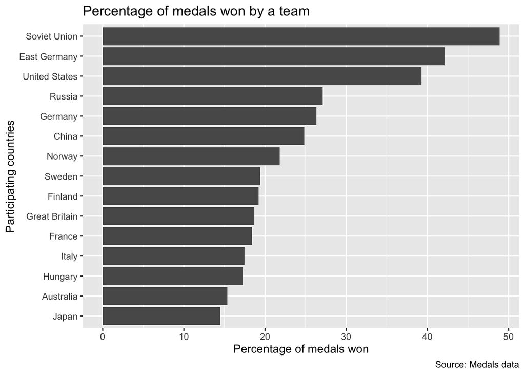

```r
library(infer)
library(dplyr)

medals_data_chi_test <- medals_data %>%
  distinct(games, team, event,medal) %>%
  mutate(medal_won=if_else(is.na(medal),"not_won","won")) %>%
  filter(team %in% top_15 ) # chi square test

medals_data_for_barplot<-medals_data_chi_test %>%
  count(team,medal_won,name = "medals_competed_won") %>% # barplot
  group_by(team) %>%
  mutate(total_medals_competed=sum(medals_competed_won)) %>%
  filter(!(medal_won=="not_won")) %>%
  mutate(percentage=100*medals_competed_won/total_medals_competed)

  ggplot2::ggplot(medals_data_for_barplot, aes(x= reorder(team,percentage), percentage)) +
  coord_flip()+
#geom_bar(stat = "identity", aes(fill = medal_won))+  # I removed percentage of medal not_won #for aesthetics and redundant information.
  geom_bar(stat = "identity")+
    labs (
    title = "Percentage of medals won by a team",
    #subtitle = "colors distinguish whether medal was won or not",
    caption = "Source: Medals data",
    y = "Percentage of medals won",
    x = "Participating countries"
  )
```

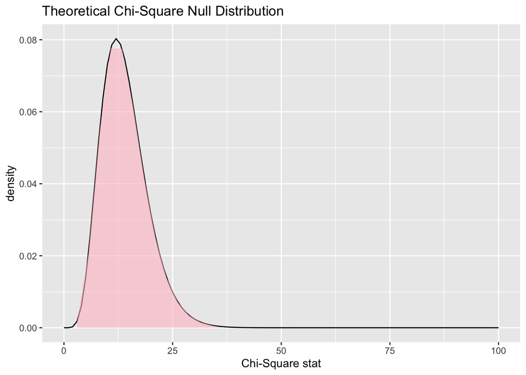

```r
#medals_data_chi_test %>%
  #select(team, medal_won) %>%
  #t_test(formula = medal_won~team)  # dont understand why t-test did not work.

team_medal_won_test<-medals_data_chi_test %>%
  chisq_test(formula = medal_won~team)

obs_chisq <- medals_data_chi_test  %>%
  chisq_stat(formula = team ~ medal_won)

chisq_null_theor <- medals_data_chi_test %>%
  specify(team ~ medal_won) %>%
  hypothesize(null = "independence") %>%
  calculate(stat = "Chisq")

visualize(chisq_null_theor, method = "theoretical") +
  shade_p_value(obs_stat = obs_chisq, direction = "left")+ xlim(0,100)
```

The horizontal barchart for percentage of medals won by a country shows that countries like United States, Soviet Union and East Germany have higher percentage of medals won by their athletes.

# Part 8

Scatterplot showing the average height and weight of competitors per sport

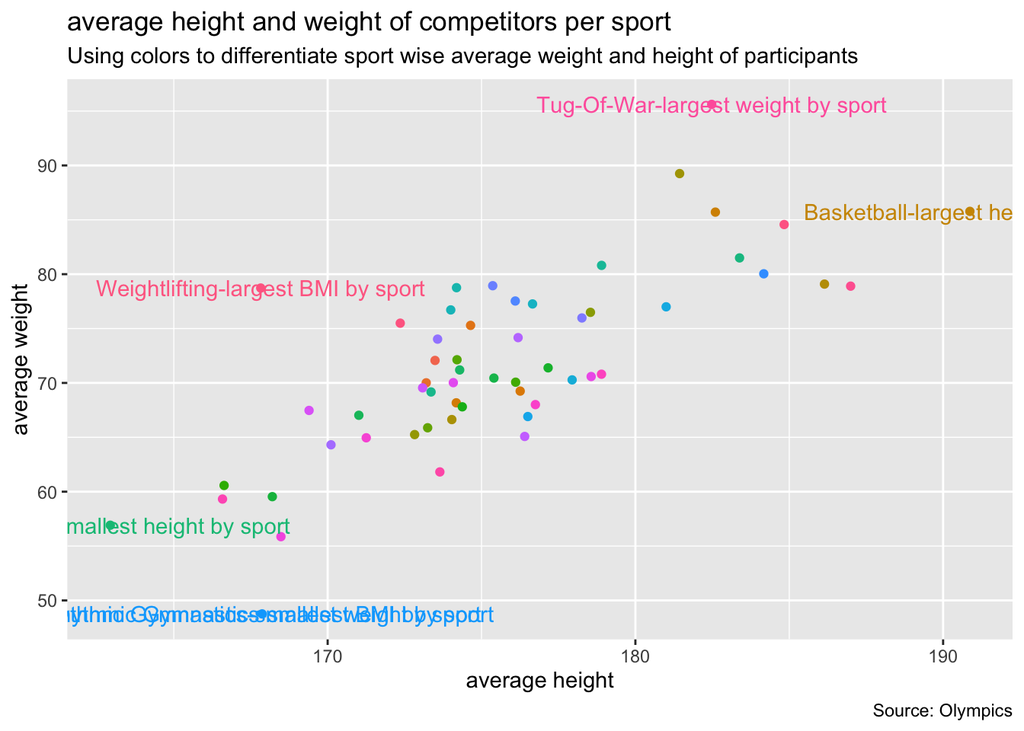

```r
medals_atheltes_left_join<-medals_data%>%
  left_join(athletes_data,
            by = c("athlete_id" ="id"))%>%
  mutate(BMI=weight/(height/100)^2)

average_weight_by_sport<-medals_atheltes_left_join%>%
  group_by(sport)%>%
  summarize(mean_weight = mean(weight, na.rm = TRUE))
average_height_by_sport<-medals_atheltes_left_join%>%
  group_by(sport)%>%
  summarize(mean_height = mean(height, na.rm = TRUE))

average_BMI_by_sport<-medals_atheltes_left_join%>%
  group_by(sport)%>%
  summarize(mean_BMI = mean(BMI, na.rm = TRUE))

largest_weight_by_sport <- average_weight_by_sport %>%
  slice(which.max(mean_weight))
smallest_weight_by_sport <- average_weight_by_sport %>%
  slice(which.min(mean_weight))
largest_height_by_sport <- average_height_by_sport %>%
  slice(which.max(mean_height))
smallest_height_by_sport <- average_height_by_sport %>%
  slice(which.min(mean_height))
largest_BMI_by_sport <- average_BMI_by_sport %>%
  slice(which.max(mean_BMI))
smallest_BMI_by_sport <- average_BMI_by_sport %>%
  slice(which.min(mean_BMI))

weight_height<-left_join(average_weight_by_sport,average_height_by_sport, by=c("sport"))
weight_height_BMI<-left_join(weight_height,average_BMI_by_sport, by=c("sport"))

ggplot2::ggplot(data= weight_height_BMI,
                aes(y=mean_weight,
                    x=mean_height,
                    color=sport)) + geom_point() +
  theme(legend.position="none")+
  geom_text(data= weight_height_BMI%>%
              slice(which.max(mean_weight)),
            aes(label=stringr::str_c(largest_weight_by_sport$sport,
                                     "largest weight by sport",sep="-")), check_overlap = T) +
  geom_text(data= weight_height_BMI%>%
              slice(which.min(mean_weight)),
            aes(label=stringr::str_c(smallest_weight_by_sport$sport,
                                     "smallest weight by sport",sep="-")), check_overlap = T) +

  geom_text(data= weight_height_BMI%>%
              slice(which.max(mean_height)),
            aes(label=stringr::str_c(largest_height_by_sport$sport,
                                     "largest height by sport",sep="-")), check_overlap = T) +

  geom_text(data= weight_height_BMI%>%
              slice(which.min(mean_height)),
            aes(label=stringr::str_c(smallest_height_by_sport$sport,
                                     "smallest height by sport",sep="-")), check_overlap = T) +

  geom_text(data= weight_height_BMI%>%
              slice(which.max(mean_BMI)),
            aes(label=stringr::str_c(largest_BMI_by_sport$sport,
                                     "largest BMI by sport",sep="-")), check_overlap = T) +

  geom_text(data= weight_height_BMI%>%
              slice(which.min(mean_BMI)),
            aes(label=stringr::str_c(smallest_BMI_by_sport$sport,
                                     "smallest BMI by sport",sep="-")), check_overlap = T) +

  labs(title = "average height and weight of competitors per sport",
       subtitle = "Using colors to differentiate sport wise average weight and height of participants",
       caption = "Source: Olympics",
       x = "average height",
       y = "average weight",
       fill = "sport")
```

# Part 9

number of medals (gold, silver and bronze given per year, facet chart: summer and winter)

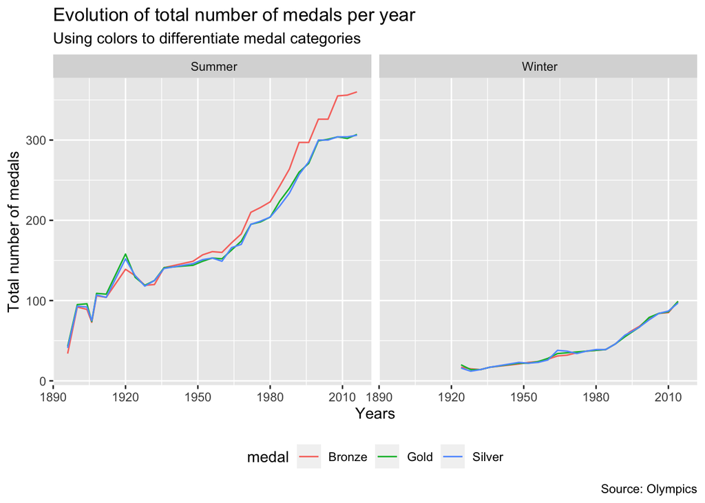

```r
medals_category_year_session<-medals_data%>%
  distinct(games,medal,team,event)%>%
  mutate(year=as.numeric(str_sub(games,start = 1L,end = 4L)))%>%
  mutate(session=str_sub(games,start = 5L))%>%
  select(-games)%>%
  arrange(desc(year))

medals_per_year<- medals_category_year_session%>%
  count(year, medal,session)


# Line plot for Part 9

medals_per_year %>% drop_na() %>%
  ggplot(mapping=aes(x=year,
                     y=n)) +
  geom_line(aes(group=medal, color=medal)) +
  theme(legend.position="bottom", legend.box = "horizontal")+
  facet_wrap(vars(session))+
  labs (title = "Evolution of total number of medals per year",
        subtitle = "Using colors to differentiate medal categories",
        caption = "Source: Olympics",
        x = "Years",
        y = "Total number of medals")
```